# Data 621 Homework 5

Sung Lee

11/29/2021

# Introduction

In this homework assignment, you will explore, analyze and model a data set containing information on approximately 12,000 commercially available wines. The variables are mostly related to the chemical properties of the wine being sold. The response variable is the number of sample cases of wine that were purchased by wine distribution companies after sampling a wine. These cases would be used to provide tasting samples to restaurants and wine stores around the United States. The more sample cases purchased, the more likely is a wine to be sold at a high end restaurant. A large wine manufacturer is studying the data in order to predict the number of wine cases ordered based upon the wine characteristics. If the wine manufacturer can predict the number of cases, then that manufacturer will be able to adjust their wine offering to maximize sales.

Your objective is to build a count regression model to predict the number of cases of wine that will be sold given certain properties of the wine. HINT: Sometimes, the fact that a variable is missing is actually predictive of the target. You can only use the variables given to you (or variables that you derive from the variables provided).

# Data Exploration

The following are the variables provided with their description.

| Variable | Description |
| --- | --- |
| INDEX | Identification Variable (do not use) |
| TARGET | Number of Cases Purchased |
| AcidIndex | Proprietary method of testing total acidity of wine by using a weighted average |
| Alcohol | Alcohol Content |
| Chlorides | Chloride content of wine |
| CitricAcid | Citric Acid Content |
| Density | Density of Wine |
| FixedAcidity | Fixed Acidity of Wine |
| FreeSulfurDioxide | Sulfur Dioxide content of wine |
| LabelAppeal | Marketing Score indicating the appeal of label design for consumers. High numbers suggest customers like the label design. Negative numbers suggest customes don’t like the design. |
| ResidualSugar | Residual Sugar of wine |
| STARS | Wine rating by a team of experts. 4 Stars = Excellent, 1 Star = Poor |
| Sulphates | Sulfate conten of wine |
| TotalSulfurDioxide | Total Sulfur Dioxide of Wine |
| VolatileAcidity | Volatile Acid content of wine |
| pH | pH of wine |

```
## VIM is ready to use.
```

```
## Suggestions and bug-reports can be submitted at: https://github.com/statistikat/VIM/issues
```

The following is a snippet of the training data:

| TARGET | FixedAcidity | VolatileAcidity | CitricAcid | ResidualSugar | Chlorides | FreeSulfurDioxide | TotalSulfurDioxide | Density | pH | Sulphates | Alcohol | LabelAppeal | AcidIndex | STARS |
| --- | --- | --- | --- | --- | --- | --- | --- | --- | --- | --- | --- | --- | --- | --- |
| 3 | 3.2 | 1.160 | -0.98 | 54.2 | -0.567 | NA | 268 | 0.9928 | 3.33 | -0.59 | 9.9 | 0 | 8 | 2 |
| 3 | 4.5 | 0.160 | -0.81 | 26.1 | -0.425 | 15 | -327 | 1.0279 | 3.38 | 0.70 | NA | -1 | 7 | 3 |
| 5 | 7.1 | 2.640 | -0.88 | 14.8 | 0.037 | 214 | 142 | 0.9952 | 3.12 | 0.48 | 22.0 | -1 | 8 | 3 |
| 3 | 5.7 | 0.385 | 0.04 | 18.8 | -0.425 | 22 | 115 | 0.9964 | 2.24 | 1.83 | 6.2 | -1 | 6 | 1 |
| 4 | 8.0 | 0.330 | -1.26 | 9.4 | NA | -167 | 108 | 0.9946 | 3.12 | 1.77 | 13.7 | 0 | 9 | 2 |
| 0 | 11.3 | 0.320 | 0.59 | 2.2 | 0.556 | -37 | 15 | 0.9994 | 3.20 | 1.29 | 15.4 | 0 | 11 | NA |

The evaluation data had a variable named `IN` which was different from the training data’s `INDEX` variable.

## Summary Analysis

Here is a summary of the training data:

```
##      TARGET      FixedAcidity    VolatileAcidity    CitricAcid
##  Min.   :0.00   Min.   :-18.10   Min.   :-2.790   Min.   :-3.240
##  1st Qu.:2.00   1st Qu.:  5.20   1st Qu.: 0.130   1st Qu.: 0.030
##  Median :3.00   Median :  6.90   Median : 0.280   Median : 0.310
##  Mean   :3.03   Mean   :  7.08   Mean   : 0.324   Mean   : 0.308
##  3rd Qu.:4.00   3rd Qu.:  9.50   3rd Qu.: 0.640   3rd Qu.: 0.580
##  Max.   :8.00   Max.   : 34.40   Max.   : 3.680   Max.   : 3.860
##
##  ResidualSugar      Chlorides    FreeSulfurDioxide TotalSulfurDioxide
##  Min.   :-127.8   Min.   :-1.2   Min.   :-555.0    Min.   :-823
##  1st Qu.:  -2.0   1st Qu.: 0.0   1st Qu.:   0.0    1st Qu.:  27
##  Median :   3.9   Median : 0.0   Median :  30.0    Median : 123
##  Mean   :   5.4   Mean   : 0.1   Mean   :  30.8    Mean   : 121
##  3rd Qu.:  15.9   3rd Qu.: 0.2   3rd Qu.:  70.0    3rd Qu.: 208
##  Max.   : 141.2   Max.   : 1.4   Max.   : 623.0    Max.   :1057
##  NA's   :616      NA's   :638    NA's   :647       NA's   :682
##     Density            pH        Sulphates       Alcohol      LabelAppeal
##  Min.   :0.888   Min.   :0.5   Min.   :-3.1   Min.   :-4.7   Min.   :-2.0000
##  1st Qu.:0.988   1st Qu.:3.0   1st Qu.: 0.3   1st Qu.: 9.0   1st Qu.:-1.0000
##  Median :0.995   Median :3.2   Median : 0.5   Median :10.4   Median : 0.0000
##  Mean   :0.994   Mean   :3.2   Mean   : 0.5   Mean   :10.5   Mean   :-0.0091
##  3rd Qu.:1.000   3rd Qu.:3.5   3rd Qu.: 0.9   3rd Qu.:12.4   3rd Qu.: 1.0000
##  Max.   :1.099   Max.   :6.1   Max.   : 4.2   Max.   :26.5   Max.   : 2.0000
##                  NA's   :395   NA's   :1210   NA's   :653
##    AcidIndex         STARS
##  Min.   : 4.00   Min.   :1
##  1st Qu.: 7.00   1st Qu.:1
##  Median : 8.00   Median :2
##  Mean   : 7.77   Mean   :2
##  3rd Qu.: 8.00   3rd Qu.:3
##  Max.   :17.00   Max.   :4
##                  NA's   :3359
```

The variables `ResidualSugar`, `Chlorides`, `FreeSulfurDioxide`, `TotalSulfurDioxide`, `pH`, `sulphates`, `Alcohol`, and `STARS` have missing values.

## Missing Values

The following uses the `mice` and `VIM` packages to look for possible patterns in missing data.

[figure not shown]

```
##      TARGET FixedAcidity VolatileAcidity CitricAcid Density LabelAppeal
## 6436      1            1               1          1       1           1
## 2239      1            1               1          1       1           1
## 669       1            1               1          1       1           1
## 247       1            1               1          1       1           1
## 341       1            1               1          1       1           1
## 123       1            1               1          1       1           1
## 42        1            1               1          1       1           1
## 16        1            1               1          1       1           1
## 335       1            1               1          1       1           1
## 123       1            1               1          1       1           1
## 37        1            1               1          1       1           1
## 10        1            1               1          1       1           1
## 21        1            1               1          1       1           1
## 8         1            1               1          1       1           1
```

[output cut: 273 more lines]

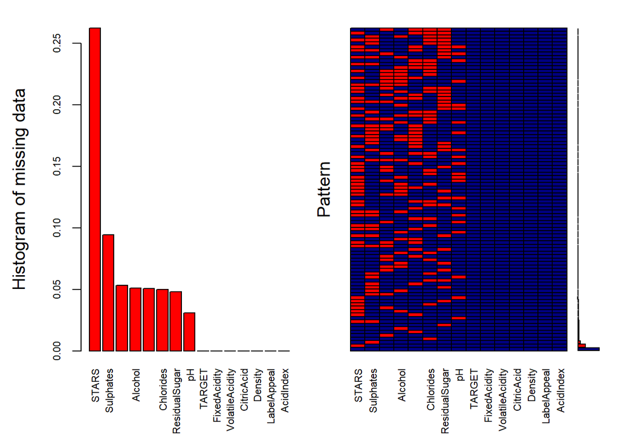

```
##
##  Variables sorted by number of missings:
##            Variable   Count
##               STARS 0.26252
##           Sulphates 0.09457
##  TotalSulfurDioxide 0.05330
##             Alcohol 0.05104
##   FreeSulfurDioxide 0.05057
##           Chlorides 0.04986
##       ResidualSugar 0.04814
##                  pH 0.03087
##              TARGET 0.00000
##        FixedAcidity 0.00000
##     VolatileAcidity 0.00000
##          CitricAcid 0.00000
##             Density 0.00000
##         LabelAppeal 0.00000
##           AcidIndex 0.00000
```

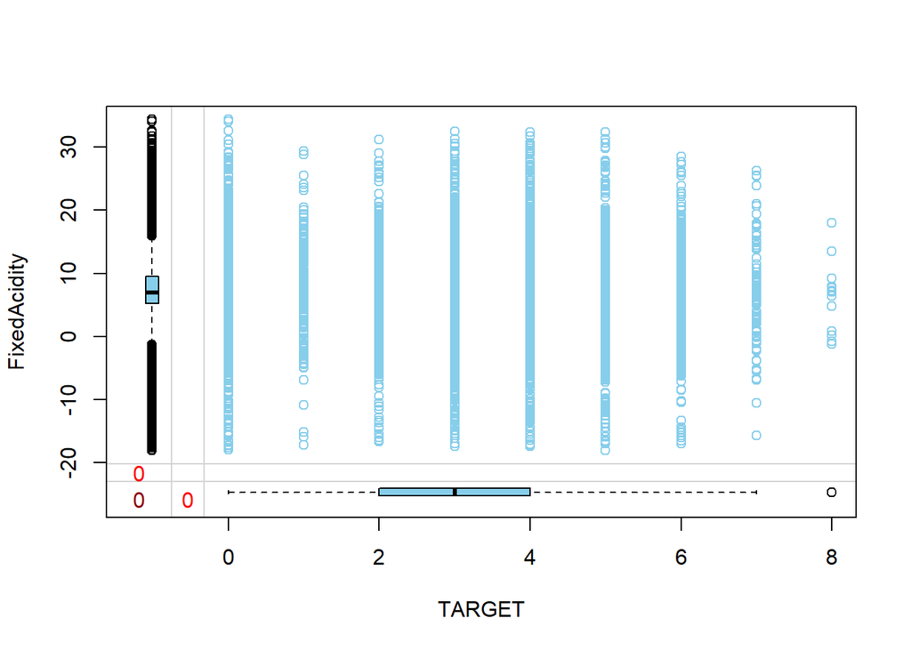

## Correlation

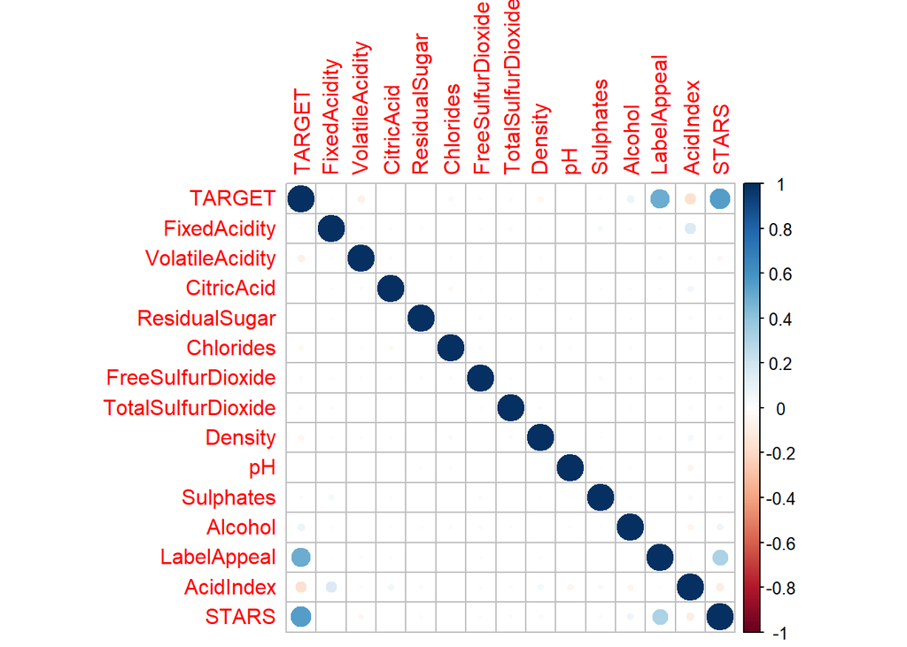

```
##                        TARGET FixedAcidity VolatileAcidity CitricAcid
## TARGET              1.0000000    -0.012538      -0.0759979  0.0023450
## FixedAcidity       -0.0125381     1.000000       0.0190110  0.0140004
## VolatileAcidity    -0.0759979     0.019011       1.0000000 -0.0234316
## CitricAcid          0.0023450     0.014000      -0.0234316  1.0000000
## ResidualSugar       0.0035196    -0.015429       0.0015280 -0.0098431
## Chlorides          -0.0304301    -0.006104       0.0148489 -0.0335609
## FreeSulfurDioxide   0.0226398     0.015438      -0.0114408  0.0121132
## TotalSulfurDioxide  0.0216021    -0.023323      -0.0007434 -0.0099175
## Density            -0.0475989     0.011574       0.0130978 -0.0169920
## pH                  0.0002199    -0.004554       0.0072030 -0.0007581
## Sulphates          -0.0212204     0.042229       0.0015161 -0.0144237
## Alcohol             0.0737771    -0.013085       0.0002603  0.0169864
## LabelAppeal         0.4979465     0.011376      -0.0202420  0.0153316
## AcidIndex          -0.1676431     0.154168       0.0250530  0.0545838
## STARS               0.5546857    -0.004937      -0.0402432  0.0071402
##                    ResidualSugar  Chlorides FreeSulfurDioxide
## TARGET                  0.003520 -0.0304301          0.022640
## FixedAcidity           -0.015429 -0.0061044          0.015438
## VolatileAcidity         0.001528  0.0148489         -0.011441
## CitricAcid             -0.009843 -0.0335609          0.012113
## ResidualSugar           1.000000  0.0041216          0.021959
## Chlorides               0.004122  1.0000000         -0.020492
## FreeSulfurDioxide       0.021959 -0.0204925          1.000000
## TotalSulfurDioxide      0.017031  0.0004189          0.013462
## Density                -0.007121  0.0206725         -0.008664
## pH                      0.017564 -0.0179702         -0.002009
## Sulphates              -0.002706  0.0026188          0.026829
## Alcohol                -0.018943 -0.0228850         -0.023867
## LabelAppeal            -0.004579 -0.0063870          0.014960
## AcidIndex              -0.020302 -0.0017134         -0.014734
## STARS                   0.019666 -0.0063243         -0.015390
##                    TotalSulfurDioxide   Density         pH Sulphates    Alcohol
## TARGET                      0.0216021 -0.047599  0.0002199 -0.021220  0.0737771
## FixedAcidity               -0.0233235  0.011574 -0.0045539  0.042229 -0.0130850
## VolatileAcidity            -0.0007434  0.013098  0.0072030  0.001516  0.0002603
## CitricAcid                 -0.0099175 -0.016992 -0.0007581 -0.014424  0.0169864
## ResidualSugar               0.0170309 -0.007121  0.0175638 -0.002706 -0.0189433
## Chlorides                   0.0004189  0.020672 -0.0179702  0.002619 -0.0228850
## FreeSulfurDioxide           0.0134617 -0.008664 -0.0020085  0.026829 -0.0238675
```

[output cut: 9 more lines]

```
## TARGET               0.4979465 -0.167643  0.554686
## FixedAcidity         0.0113760  0.154168 -0.004937
## VolatileAcidity     -0.0202420  0.025053 -0.040243
## CitricAcid           0.0153316  0.054584  0.007140
## ResidualSugar       -0.0045793 -0.020302  0.019666
## Chlorides           -0.0063870 -0.001713 -0.006324
## FreeSulfurDioxide    0.0149601 -0.014734 -0.015390
## TotalSulfurDioxide  -0.0027237 -0.022129  0.022095
## Density             -0.0180944  0.047779 -0.028492
## pH                   0.0002182 -0.053713 -0.004400
## Sulphates            0.0037687  0.031072 -0.023135
## Alcohol             -0.0006449 -0.055892  0.064854
## LabelAppeal          1.0000000  0.010301  0.318897
## AcidIndex            0.0103010  1.000000 -0.095483
## STARS                0.3188970 -0.095483  1.000000
```

## Distributions

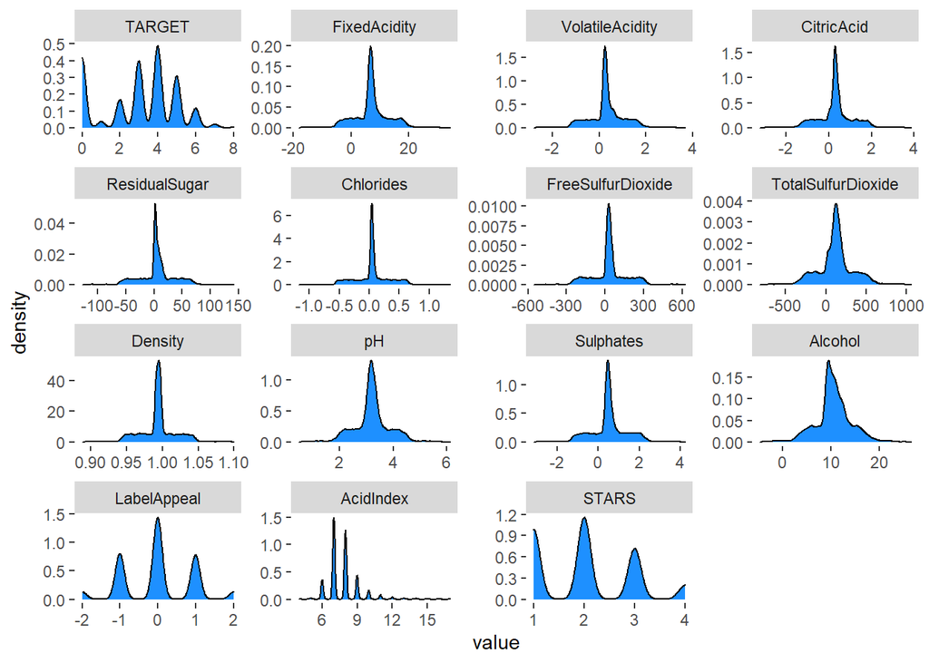

# Data Preparation

The following is a snippet of the training data along with an updated summary after imputation.

|  | TARGET | FixedAcidity | VolatileAcidity | CitricAcid | ResidualSugar | Chlorides | FreeSulfurDioxide | TotalSulfurDioxide | Density | pH | Sulphates | Alcohol | LabelAppeal | AcidIndex | STARS |
| --- | --- | --- | --- | --- | --- | --- | --- | --- | --- | --- | --- | --- | --- | --- | --- |
| 1 | 3 | 3.2 | 1.160 | -0.98 | 54.2 | -0.567 | 57 | 268 | 0.9928 | 3.33 | -0.59 | 9.9 | 0 | 8 | 2 |
| 2 | 3 | 4.5 | 0.160 | -0.81 | 26.1 | -0.425 | 15 | -327 | 1.0279 | 3.38 | 0.70 | 10.7 | -1 | 7 | 3 |
| 3 | 5 | 7.1 | 2.640 | -0.88 | 14.8 | 0.037 | 214 | 142 | 0.9952 | 3.12 | 0.48 | 22.0 | -1 | 8 | 3 |
| 4 | 3 | 5.7 | 0.385 | 0.04 | 18.8 | -0.425 | 22 | 115 | 0.9964 | 2.24 | 1.83 | 6.2 | -1 | 6 | 1 |
| 5 | 4 | 8.0 | 0.330 | -1.26 | 9.4 | -0.283 | -167 | 108 | 0.9946 | 3.12 | 1.77 | 13.7 | 0 | 9 | 2 |
| 6 | 0 | 11.3 | 0.320 | 0.59 | 2.2 | 0.556 | -37 | 15 | 0.9994 | 3.20 | 1.29 | 15.4 | 0 | 11 | 1 |

```
##      TARGET      FixedAcidity    VolatileAcidity    CitricAcid
##  Min.   :0.00   Min.   :-18.10   Min.   :-2.790   Min.   :-3.240
##  1st Qu.:2.00   1st Qu.:  5.20   1st Qu.: 0.130   1st Qu.: 0.030
##  Median :3.00   Median :  6.90   Median : 0.280   Median : 0.310
##  Mean   :3.03   Mean   :  7.08   Mean   : 0.324   Mean   : 0.308
##  3rd Qu.:4.00   3rd Qu.:  9.50   3rd Qu.: 0.640   3rd Qu.: 0.580
##  Max.   :8.00   Max.   : 34.40   Max.   : 3.680   Max.   : 3.860
##  ResidualSugar       Chlorides       FreeSulfurDioxide TotalSulfurDioxide
##  Min.   :-127.80   Min.   :-1.1710   Min.   :-555.0    Min.   :-823
##  1st Qu.:  -2.30   1st Qu.:-0.0310   1st Qu.:  -1.8    1st Qu.:  27
##  Median :   3.85   Median : 0.0460   Median :  30.0    Median : 123
##  Mean   :   5.31   Mean   : 0.0551   Mean   :  30.3    Mean   : 120
##  3rd Qu.:  15.80   3rd Qu.: 0.1560   3rd Qu.:  70.0    3rd Qu.: 208
##  Max.   : 141.15   Max.   : 1.3510   Max.   : 623.0    Max.   :1057
##     Density            pH         Sulphates         Alcohol
##  Min.   :0.888   Min.   :0.48   Min.   :-3.130   Min.   :-4.7
##  1st Qu.:0.988   1st Qu.:2.95   1st Qu.: 0.280   1st Qu.: 9.0
##  Median :0.995   Median :3.20   Median : 0.500   Median :10.4
##  Mean   :0.994   Mean   :3.21   Mean   : 0.532   Mean   :10.5
##  3rd Qu.:1.000   3rd Qu.:3.47   3rd Qu.: 0.870   3rd Qu.:12.4
##  Max.   :1.099   Max.   :6.13   Max.   : 4.240   Max.   :26.5
##   LabelAppeal        AcidIndex         STARS
##  Min.   :-2.0000   Min.   : 4.00   Min.   :1.00
##  1st Qu.:-1.0000   1st Qu.: 7.00   1st Qu.:1.00
##  Median : 0.0000   Median : 8.00   Median :2.00
##  Mean   :-0.0091   Mean   : 7.77   Mean   :1.87
##  3rd Qu.: 1.0000   3rd Qu.: 8.00   3rd Qu.:2.00
##  Max.   : 2.0000   Max.   :17.00   Max.   :4.00
```

## Correlation

Here is an updated correlation after the data imputation.

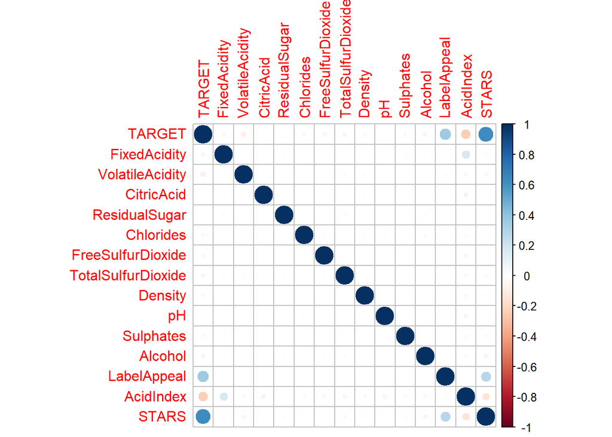

```
##                       TARGET FixedAcidity VolatileAcidity CitricAcid
## TARGET              1.000000    -0.049011       -0.088793   0.008685
## FixedAcidity       -0.049011     1.000000        0.012375   0.014240
## VolatileAcidity    -0.088793     0.012375        1.000000  -0.016953
## CitricAcid          0.008685     0.014240       -0.016953   1.000000
## ResidualSugar       0.014743    -0.021184       -0.006302  -0.006820
## Chlorides          -0.038427     0.001648       -0.002361  -0.004717
## FreeSulfurDioxide   0.046095     0.008186       -0.007708   0.006930
## TotalSulfurDioxide  0.053754    -0.018136       -0.022749   0.004616
## Density            -0.035518     0.006477        0.014735  -0.013952
## pH                 -0.010369    -0.009932        0.012457  -0.007147
## Sulphates          -0.039448     0.029702       -0.005163  -0.011040
## Alcohol             0.059805    -0.010153        0.004845   0.015732
## LabelAppeal         0.356500    -0.003366       -0.016987   0.008650
## AcidIndex          -0.246049     0.178437        0.044642   0.065697
## STARS               0.623718    -0.027028       -0.049589   0.005788
##                    ResidualSugar Chlorides FreeSulfurDioxide TotalSulfurDioxide
## TARGET                 0.0147427 -0.038427         0.0460947           0.053754
## FixedAcidity          -0.0211837  0.001648         0.0081860          -0.018136
## VolatileAcidity       -0.0063022 -0.002361        -0.0077078          -0.022749
## CitricAcid            -0.0068203 -0.004717         0.0069303           0.004616
## ResidualSugar          1.0000000 -0.007033         0.0151798           0.025137
## Chlorides             -0.0070328  1.000000        -0.0202831          -0.014754
## FreeSulfurDioxide      0.0151798 -0.020283         1.0000000           0.015574
## TotalSulfurDioxide     0.0251371 -0.014754         0.0155736           1.000000
## Density                0.0018045  0.025289        -0.0006445           0.011742
## pH                     0.0137463 -0.019377         0.0037174          -0.004573
## Sulphates             -0.0038658  0.002372         0.0072371          -0.001592
## Alcohol               -0.0213024 -0.021335        -0.0177069          -0.017818
## LabelAppeal            0.0007362  0.009836         0.0099016          -0.006174
## AcidIndex             -0.0092240  0.027716        -0.0417547          -0.047492
## STARS                  0.0179530 -0.013839         0.0097841           0.034320
##                       Density        pH  Sulphates   Alcohol LabelAppeal
## TARGET             -0.0355175 -0.010369 -0.0394478  0.059805   0.3565005
## FixedAcidity        0.0064765 -0.009932  0.0297019 -0.010153  -0.0033664
## VolatileAcidity     0.0147349  0.012457 -0.0051635  0.004845  -0.0169870
## CitricAcid         -0.0139522 -0.007147 -0.0110403  0.015732   0.0086502
## ResidualSugar       0.0018045  0.013746 -0.0038658 -0.021302   0.0007362
## Chlorides           0.0252892 -0.019377  0.0023723 -0.021335   0.0098362
## FreeSulfurDioxide  -0.0006445  0.003717  0.0072371 -0.017707   0.0099016
```

[output cut: 9 more lines]

```
## TARGET             -0.246049  0.623718
## FixedAcidity        0.178437 -0.027028
## VolatileAcidity     0.044642 -0.049589
## CitricAcid          0.065697  0.005788
## ResidualSugar      -0.009224  0.017953
## Chlorides           0.027716 -0.013839
## FreeSulfurDioxide  -0.041755  0.009784
## TotalSulfurDioxide -0.047492  0.034320
## Density             0.040413 -0.022667
## pH                 -0.058631 -0.006220
## Sulphates           0.034070 -0.029373
## Alcohol            -0.038963  0.059860
## LabelAppeal         0.024755  0.288941
## AcidIndex           1.000000 -0.143233
## STARS              -0.143233  1.000000
```

## Distributions

Here are updated distributions for the training data after imputation.

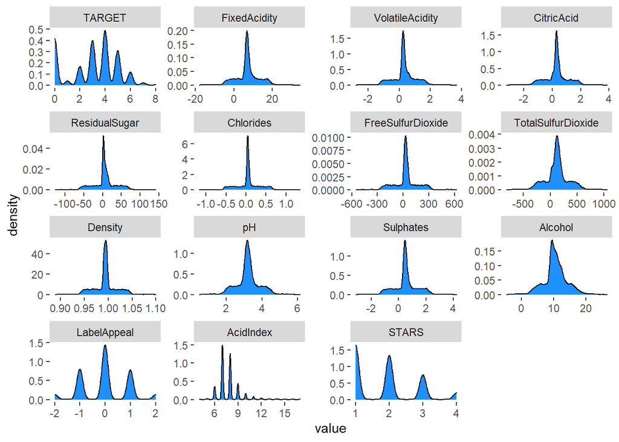

# Build Models

Next, we will work on building models and finding the best fit to predict the number of cases sold. Before we move on, let’s split the training data (80/20).

## Splitting Data

Here are snippets of the split training data.

|  | TARGET | FixedAcidity | VolatileAcidity | CitricAcid | ResidualSugar | Chlorides | FreeSulfurDioxide | TotalSulfurDioxide | Density | pH | Sulphates | Alcohol | LabelAppeal | AcidIndex | STARS |
| --- | --- | --- | --- | --- | --- | --- | --- | --- | --- | --- | --- | --- | --- | --- | --- |
| 1 | 3 | 3.2 | 1.160 | -0.98 | 54.2 | -0.567 | 57 | 268 | 0.9928 | 3.33 | -0.59 | 9.9 | 0 | 8 | 2 |
| 2 | 3 | 4.5 | 0.160 | -0.81 | 26.1 | -0.425 | 15 | -327 | 1.0279 | 3.38 | 0.70 | 10.7 | -1 | 7 | 3 |
| 3 | 5 | 7.1 | 2.640 | -0.88 | 14.8 | 0.037 | 214 | 142 | 0.9952 | 3.12 | 0.48 | 22.0 | -1 | 8 | 3 |
| 4 | 3 | 5.7 | 0.385 | 0.04 | 18.8 | -0.425 | 22 | 115 | 0.9964 | 2.24 | 1.83 | 6.2 | -1 | 6 | 1 |
| 7 | 0 | 7.7 | 0.290 | -0.40 | 21.5 | 0.060 | 287 | 156 | 0.9957 | 3.49 | 1.21 | 10.3 | 0 | 8 | 2 |
| 8 | 4 | 6.5 | -1.220 | 0.34 | 1.4 | 0.040 | 523 | 551 | 1.0324 | 3.20 | 0.39 | 11.6 | 1 | 7 | 3 |

|  | TARGET | FixedAcidity | VolatileAcidity | CitricAcid | ResidualSugar | Chlorides | FreeSulfurDioxide | TotalSulfurDioxide | Density | pH | Sulphates | Alcohol | LabelAppeal | AcidIndex | STARS |
| --- | --- | --- | --- | --- | --- | --- | --- | --- | --- | --- | --- | --- | --- | --- | --- |
| 5 | 4 | 8.0 | 0.33 | -1.26 | 9.4 | -0.283 | -167 | 108 | 0.9946 | 3.12 | 1.77 | 13.7 | 0 | 9 | 2 |
| 6 | 0 | 11.3 | 0.32 | 0.59 | 2.2 | 0.556 | -37 | 15 | 0.9994 | 3.20 | 1.29 | 15.4 | 0 | 11 | 1 |
| 13 | 3 | 6.0 | 0.33 | -1.06 | 3.0 | 0.518 | 5 | 378 | 0.9664 | 3.55 | -0.86 | 3.9 | 1 | 7 | 2 |
| 17 | 0 | 7.9 | 0.60 | 0.06 | 50.4 | 0.069 | 15 | 339 | 0.9964 | 3.30 | 0.46 | 3.9 | 1 | 9 | 1 |
| 18 | 4 | -1.3 | 0.22 | 2.95 | -53.0 | 0.541 | -85 | -266 | 0.9967 | 3.61 | 0.82 | 10.0 | 0 | 8 | 3 |
| 26 | 0 | 2.7 | -1.02 | -0.53 | -44.0 | 0.174 | -60 | 72 | 0.9952 | 3.18 | 0.40 | 15.2 | -1 | 7 | 1 |

## Model 1

For the first model, I will use a Poisson Regression utilizing all of the variables.

```
##
## Call:
## glm(formula = TARGET ~ ., family = poisson(), data = training)
##
## Deviance Residuals:
##    Min      1Q  Median      3Q     Max
## -2.929  -0.687   0.126   0.632   2.660
##
## Coefficients:
##                      Estimate Std. Error z value             Pr(>|z|)
## (Intercept)         1.5218379  0.2194249    6.94       0.000000000004 ***
## FixedAcidity        0.0000352  0.0009136    0.04              0.96928
## VolatileAcidity    -0.0407278  0.0072627   -5.61       0.000000020493 ***
## CitricAcid          0.0119309  0.0065667    1.82              0.06924 .
## ResidualSugar       0.0000445  0.0001669    0.27              0.78985
## Chlorides          -0.0560098  0.0179377   -3.12              0.00179 **
## FreeSulfurDioxide   0.0001164  0.0000380    3.06              0.00221 **
## TotalSulfurDioxide  0.0000853  0.0000248    3.45              0.00057 ***
## Density            -0.3012585  0.2158020   -1.40              0.16272
## pH                 -0.0238653  0.0083435   -2.86              0.00423 **
## Sulphates          -0.0139759  0.0061086   -2.29              0.02214 *
## Alcohol             0.0030091  0.0015373    1.96              0.05031 .
## LabelAppeal         0.1429899  0.0067921   21.05 < 0.0000000000000002 ***
## AcidIndex          -0.1006120  0.0050477  -19.93 < 0.0000000000000002 ***
## STARS               0.3388111  0.0062866   53.89 < 0.0000000000000002 ***
## ---
## Signif. codes:  0 '***' 0.001 '**' 0.01 '*' 0.05 '.' 0.1 ' ' 1
##
## (Dispersion parameter for poisson family taken to be 1)
##
##     Null deviance: 18359  on 10237  degrees of freedom
## Residual deviance: 12838  on 10223  degrees of freedom
## AIC: 38405
##
## Number of Fisher Scoring iterations: 5
```

```
## y ~ VolatileAcidity + Chlorides + FreeSulfurDioxide + TotalSulfurDioxide +
##     pH + Sulphates + LabelAppeal + AcidIndex + STARS
## <environment: 0x000000003030ae78>
```

The significant variables in this model are `VolatileAcidity`, `Chlorides`, `FreeSulfurDioxide`, `TotalSulfurDioxide`, `pH`, `Sulphates`, `LabelAppeal`, `AcidIndex`, `STARS`.

Let’s see how this model works with the evaluation data.

The RMSE (root-mean-square error) for the training data is 2.6181.  
The RMSE (root-mean-square error) for the evaluation data is 2.6124.  
The AIC for the model is 38404.543.

## Model 2

For model 2, I will use `LabelAppeal`, `STARS`, `VolatileAcidity`, `ToTalSulfurDioxide`, and `Alcohol`. For the variables `LabelAppeal` and `STARS`, I will treat them as factors instead of using their numeric form.

This is a summary of model 2.

```
##
## Call:
## glm(formula = TARGET ~ as.factor(LabelAppeal) + as.factor(STARS) +
##     VolatileAcidity + TotalSulfurDioxide + Alcohol, family = poisson(),
##     data = training)
##
## Deviance Residuals:
##     Min       1Q   Median       3Q      Max
## -3.0218  -0.6092   0.0569   0.5499   2.4997
##
## Coefficients:
##                            Estimate Std. Error z value             Pr(>|z|)
## (Intercept)               0.1418551  0.0441371    3.21              0.00131 **
## as.factor(LabelAppeal)-1  0.2038417  0.0425212    4.79        0.00000163578 ***
## as.factor(LabelAppeal)0   0.3868517  0.0414303    9.34 < 0.0000000000000002 ***
## as.factor(LabelAppeal)1   0.5077338  0.0421080   12.06 < 0.0000000000000002 ***
## as.factor(LabelAppeal)2   0.6091011  0.0473181   12.87 < 0.0000000000000002 ***
## as.factor(STARS)2         0.6737681  0.0149197   45.16 < 0.0000000000000002 ***
## as.factor(STARS)3         0.8775238  0.0162866   53.88 < 0.0000000000000002 ***
## as.factor(STARS)4         1.0102842  0.0232268   43.50 < 0.0000000000000002 ***
## VolatileAcidity          -0.0457638  0.0072935   -6.27        0.00000000035 ***
## TotalSulfurDioxide        0.0000892  0.0000247    3.62              0.00029 ***
## Alcohol                   0.0058399  0.0015372    3.80              0.00015 ***
## ---
## Signif. codes:  0 '***' 0.001 '**' 0.01 '*' 0.05 '.' 0.1 ' ' 1
##
## (Dispersion parameter for poisson family taken to be 1)
##
##     Null deviance: 18359  on 10237  degrees of freedom
## Residual deviance: 12659  on 10227  degrees of freedom
## AIC: 38218
##
## Number of Fisher Scoring iterations: 5
```

Let’s see how this model works with the evaluation data.

The RMSE (root-mean-square error) for the training data is 2.6176.  
The RMSE (root-mean-square error) for the evaluation data is 2.6119.  
The AIC for the model is 38217.6891.

## Model 3

This model will be a multiple linear regression model.

```
##
## Call:
## lm(formula = TARGET ~ ., data = training)
##
## Residuals:
##    Min     1Q Median     3Q    Max
## -4.306 -1.013  0.167  1.031  4.398
##
## Coefficients:
##                      Estimate Std. Error t value             Pr(>|t|)
## (Intercept)         3.7246827  0.5379785    6.92      0.0000000000047 ***
## FixedAcidity        0.0001189  0.0022559    0.05              0.95798
## VolatileAcidity    -0.1214826  0.0178646   -6.80      0.0000000000110 ***
## CitricAcid          0.0338893  0.0162883    2.08              0.03750 *
## ResidualSugar       0.0001530  0.0004127    0.37              0.71090
## Chlorides          -0.1775858  0.0439922   -4.04      0.0000545894724 ***
## FreeSulfurDioxide   0.0003278  0.0000943    3.48              0.00051 ***
## TotalSulfurDioxide  0.0002347  0.0000609    3.85              0.00012 ***
## Density            -0.8626038  0.5304145   -1.63              0.10392
## pH                 -0.0613337  0.0205449   -2.99              0.00284 **
## Sulphates          -0.0392567  0.0150702   -2.60              0.00920 **
## Alcohol             0.0123075  0.0037665    3.27              0.00109 **
## LabelAppeal         0.4362817  0.0164944   26.45 < 0.0000000000000002 ***
## AcidIndex          -0.2465454  0.0109136  -22.59 < 0.0000000000000002 ***
## STARS               1.1595364  0.0167259   69.33 < 0.0000000000000002 ***
## ---
## Signif. codes:  0 '***' 0.001 '**' 0.01 '*' 0.05 '.' 0.1 ' ' 1
##
## Residual standard error: 1.42 on 10223 degrees of freedom
## Multiple R-squared:  0.46,   Adjusted R-squared:  0.46
## F-statistic:  623 on 14 and 10223 DF,  p-value: <0.0000000000000002
```

The model explains 46% of the data.

# Selecting Models

## Predictions

|  | TARGET | FixedAcidity | VolatileAcidity | CitricAcid | ResidualSugar | Chlorides | FreeSulfurDioxide | TotalSulfurDioxide | Density | pH | Sulphates | Alcohol | LabelAppeal | AcidIndex | STARS |
| --- | --- | --- | --- | --- | --- | --- | --- | --- | --- | --- | --- | --- | --- | --- | --- |
| 1 | 1 | 5.4 | -0.860 | 0.27 | -10.7 | 0.092 | 23 | 398 | 0.9853 | 5.02 | 0.64 | 12.30 | -1 | 6 | 2 |
| 2 | 1 | 12.4 | 0.385 | -0.76 | -19.7 | 1.169 | -37 | 68 | 0.9905 | 3.37 | 1.09 | 16.00 | 0 | 6 | 2 |
| 3 | 1 | 7.2 | 1.750 | 0.17 | -33.0 | 0.065 | 9 | 76 | 1.0464 | 4.61 | 0.68 | 8.55 | 0 | 8 | 1 |
| 4 | 1 | 6.2 | 0.100 | 1.80 | 1.0 | -0.179 | 104 | 89 | 0.9888 | 3.20 | 2.11 | 12.30 | -1 | 8 | 1 |
| 5 | 1 | 11.4 | 0.210 | 0.28 | 1.2 | 0.038 | 70 | 53 | 1.0290 | 2.54 | -0.07 | 4.80 | 0 | 10 | 2 |
| 6 | 2 | 17.6 | 0.040 | -1.15 | 1.4 | 0.535 | -250 | 140 | 0.9503 | 3.06 | -0.02 | 11.40 | 1 | 8 | 4 |